# Team file

Sonia Thomas and John Nownes

3/11/2020

## Lab 4

### Part one: Cleaning the Data

#### Questions 1-3

```r
defClean<- defense %>%
  mutate(Name =as.factor(Name)) %>%
  mutate(Opponent_Opponent = as.factor(Opponent_Opponent)) %>%
  mutate_at(vars(contains("Tackles")), funs(as.numeric)) %>%
  mutate_at(vars(contains("Turnover")), funs(as.numeric)) %>%
  mutate_at(vars(contains("Pass")), funs(as.numeric))

str(defClean)
```

```
## Classes 'tbl_df', 'tbl' and 'data.frame':    502 obs. of  11 variables:
##  $ Name             : Factor w/ 43 levels "Akers, Landen",..: 40 40 40 40 40 40 40 40 40 40 ...
##  $ Opponent_Opponent: Factor w/ 13 levels "Baylor","Iowa",..: 12 2 11 1 8 13 10 7 6 9 ...
##  $ Tackles_Solo     : num  4 4 3 4 3 1 7 3 6 5 ...
##  $ Tackles_ASST     : num  4 7 5 2 2 1 1 2 1 5 ...
##  $ Tackles_TFL      : num  0 0 0 0 1 0 0 0 1 1 ...
##  $ Tackles_Sack     : num  0 0 0 0 0 0 0 0 0 1 ...
##  $ Turnover_FF      : num  0 0 0 0 0 0 0 0 0 0 ...
##  $ Turnover_FR      : num  0 0 0 0 0 0 0 0 0 0 ...
##  $ Turnover_INT     : num  0 0 1 0 0 0 0 0 1 0 ...
##  $ Pass_QBH         : num  1 0 0 0 0 0 0 0 1 0 ...
##  $ Pass_PB          : num  1 2 0 0 0 1 0 0 0 0 ...
```

```r
offClean<- offense %>%
  mutate(Name =as.factor(Name)) %>%
  mutate(Opponent_Opponent = as.factor(Opponent_Opponent)) %>%
  mutate_at(vars(contains("Rushing")), funs(as.numeric)) %>%
  mutate_at(vars(contains("Receiving")), funs(as.numeric)) %>%
  mutate_at(vars(contains("Passing")), funs(as.numeric))

str(offClean)
```

```
## Classes 'tbl_df', 'tbl' and 'data.frame':    195 obs. of  12 variables:
##  $ Name             : Factor w/ 17 levels "Akers, Landen",..: 1 1 1 1 1 1 1 1 1 1 ...
##  $ Opponent_Opponent: Factor w/ 13 levels "Baylor","Iowa",..: 12 2 11 1 8 13 10 7 6 9 ...
##  $ Rushing_ATT      : num  0 0 1 0 0 0 0 0 0 0 ...
##  $ Rushing_YDS      : num  0 0 8 0 0 0 0 0 0 0 ...
##  $ Rushing_TD       : num  0 0 0 0 0 0 0 0 0 0 ...
##  $ Receiving_REC    : num  1 0 0 0 1 0 0 4 0 1 ...
##  $ Receiving_YDS    : num  21 0 0 0 32 0 0 39 0 7 ...
##  $ Receiving_TD     : num  0 0 0 0 0 0 0 0 0 0 ...
##  $ Passing_CMP-ATT  : num  NA NA NA NA NA NA NA NA NA NA ...
##  $ Passing_YDS      : num  NA NA NA NA NA NA NA NA NA NA ...
##  $ Passing_TD       : num  NA NA NA NA NA NA NA NA NA NA ...
##  $ Passing_INT      : num  NA NA NA NA NA NA NA NA NA NA ...
```

```r
bioClean<- bio %>%
  mutate(Name =as.factor(Name)) %>%
  mutate_at(vars(contains("Weight")), funs(as.numeric)) %>%
  separate(Height, into = c("ft", "inches")) %>%
  mutate(Height = as.numeric(ft)*12 + as.numeric(inches)) %>%
  select(-c(ft, inches)) %>%
  select(1:2, Height, everything())

str(bioClean)
```

```
## Classes 'tbl_df', 'tbl' and 'data.frame':    105 obs. of  7 variables:
##  $ Name      : Factor w/ 105 levels "Akers, Landen",..: 1 2 3 4 5 6 7 8 9 10 ...
##  $ Position  : chr  "Wide Receiver" "Tight End" "Wide Receiver" "Placekicker" ...
##  $ Height    : num  72 79 77 72 72 75 74 74 72 78 ...
##  $ Weight    : num  188 245 204 195 190 235 255 285 300 215 ...
##  $ Class     : chr  "Redshirt Senior" "Redshirt Senior" "Redshirt Freshman" "Redshirt Senior" ...
##  $ Hometown  : chr  "Cedar Rapids, Iowa" "Nixa, Mo." "Seffner, Fla." "Naperville, Ill." ...
##  $ Highschool: chr  "Washington" "Nixa" "Armwood" "Central" ...
```

### Part two: Tidying (1)

1. ```r
   defClean2 = defClean %>%
     pivot_longer(Tackles_Solo:Pass_PB, names_to = 'Statistic')
   ```

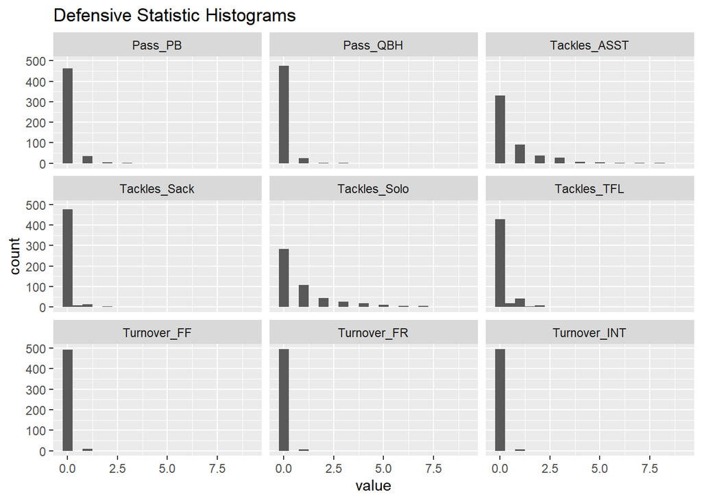

   ```r
   defClean2 %>%
     ggplot(aes(value)) + geom_histogram(binwidth = .5) + facet_wrap(~Statistic) + ggtitle("Defensive Statistic Histograms")
   ```

   - Looking at the above plot of all the defensive histograms, it is clear that the three turnover categories (forced fumble, fumble recovery, and interceptions) are the most rare defensive statistics. Sacks are also quite rare as well.

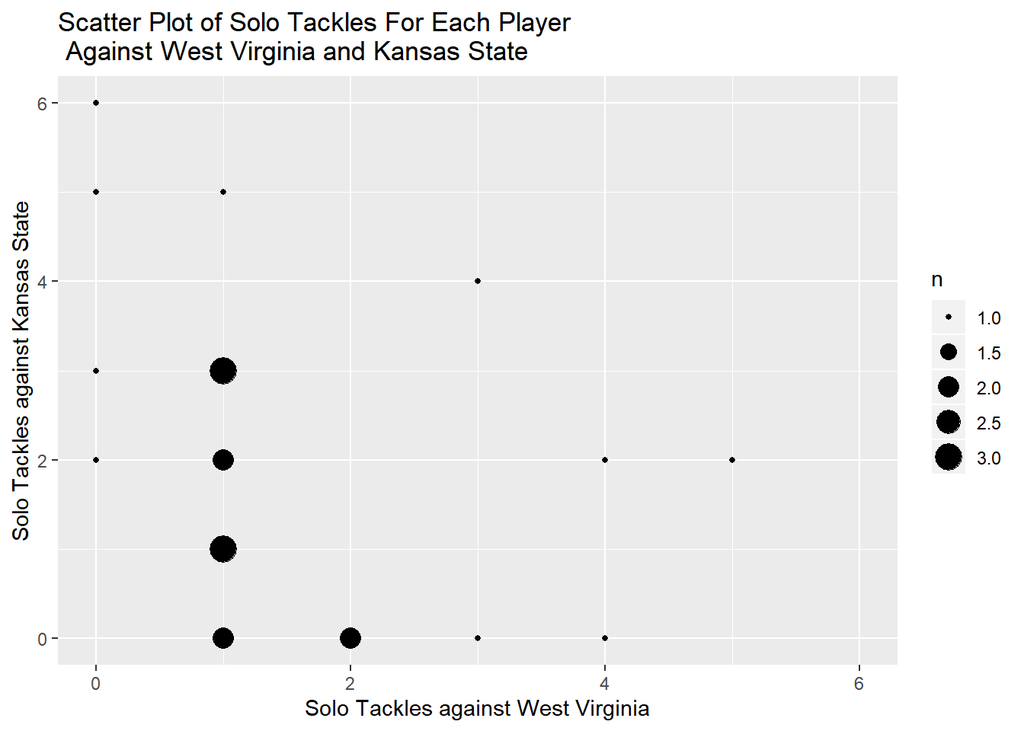

   ```r
   dat2_3 = defClean2 %>%
     filter(Opponent_Opponent == "West Virginia" | Opponent_Opponent == "Kansas State", Statistic == "Tackles_Solo") %>%
     pivot_wider(names_from = Opponent_Opponent, values_from =  value)

   dat2_3$`West Virginia`[is.na(dat2_3$`West Virginia`)] = 0
   dat2_3$`Kansas State`[is.na(dat2_3$`Kansas State`)] = 0
   dat2_3 = dat2_3 %>%
     filter(`West Virginia` != 0 | `Kansas State` != 0)

   p = dat2_3 %>%
     ggplot(aes(x = `West Virginia`, y = `Kansas State`)) + geom_count() + coord_cartesian(xlim = c(0,6))
   p = p + ggtitle("Scatter Plot of Solo Tackles For Each Player\n Against West Virginia and Kansas State")
   p + xlab("Solo Tackles against West Virginia") + ylab("Solo Tackles against Kansas State")
   ```

   - Iowa State had a better defense against Kansas State, based on the comparison of the total solo tackles against each team. From the plot above, you can tell that most individual players recorded a higher number of solo tackles against Kansas State than they did against West Virginia. In addition, by summing the total number of solo tackles against each team, we see that ISU tallied 45 total solo tackles against Kansas State and only 34 total solo tackles against West Virginia.

### Part two: Tidying (2)

1. ```r
   bioClean <- bioClean %>%
     separate(col=Hometown, into=c('City', 'State'), sep=',')

   head(bioClean, n=3)
   ```

   ```
   ## # A tibble: 3 x 8
   ##   Name         Position    Height Weight Class        City     State  Highschool
   ##   <fct>        <chr>        <dbl>  <dbl> <chr>        <chr>    <chr>  <chr>
   ## 1 Akers, Land~ Wide Recei~     72    188 Redshirt Se~ Cedar R~ " Iow~ Washington
   ## 2 Allen, Chase Tight End       79    245 Redshirt Se~ Nixa     " Mo." Nixa
   ## 3 Anderson, E~ Wide Recei~     77    204 Redshirt Fr~ Seffner  " Fla~ Armwood
   ```

2. ```r
   table(bioClean$State)
   ```

   ```
   ##
   ##      Ariz.       Ark.  Australia     Calif.       Fla.        Ga.       Ill.
   ##          4          1          1          3         10          4          5
   ##       Iowa       Kan.      Mich.      Minn.      Miss.        Mo.       Ohio
   ##         35          3          4          4          1          6          7
   ##      Okla.        Pa.       S.D.      Texas       Wis.
   ##          2          1          2          6          6
   ```

   - The output above you can see how many players are from each state. You can see that most players are from Iowa.

### Part three: Joining data frames

1. ```r
   join = offClean %>%
     left_join(bioClean, b= "Name")
   ```

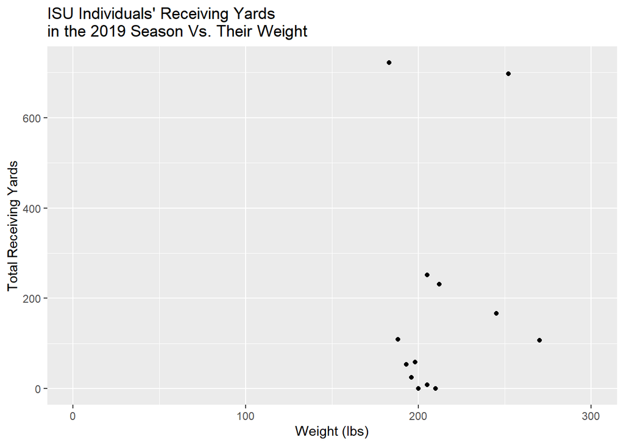

   ```r
   join$Name = as.factor(join$Name)
   join$Receiving_YDS[is.na(join$Receiving_YDS)] = 0

   dat3_2 = join %>%
     group_by(join$Name) %>%
     summarise(
       Total_Receiving_Yards = sum(Receiving_YDS),
       Weight = mean(Weight)
     ) %>%
     drop_na()

   dat3_2 %>%
     ggplot(aes(x= Weight, y = Total_Receiving_Yards)) + geom_point() + xlim(c(0,300)) + xlab("Weight (lbs)") + ylab("Total Receiving Yards") + ggtitle("ISU Individuals' Receiving Yards\nin the 2019 Season Vs. Their Weight")
   ```

   - Based on the above scatterplot, it is fair to say that there is no clear relationship between the weight of a player and the receiving yards they accumulated during the 2019 season. This can be explained by considering the fact that different teams emphasize different physical traits in their receivers. For example, one coach might prefer to have heavier, stronger, but slower receivers while a different coach might prefer to have lighter, but quicker receivers. With this in mind, weight cannot be seen as directly correlated to receiving yards, and other physical measurements such as speed must be included with weight to yield a clear relationship to receiving yards.

3. ```r
   defOff<- full_join(offClean, defClean, by= c('Opponent_Opponent', 'Name'))
   defOff2<- select(defOff, -c('Passing_CMP-ATT')) %>%
     distinct(defOff, Name, Opponent_Opponent, .keep_all = TRUE)

   avgISU<- defOff2 %>%
     mutate(Rushing_ATT = sum(Rushing_ATT, na.rm = TRUE)) %>%
     mutate(Rushing_YDS = sum(Rushing_YDS, na.rm = TRUE)) %>%
     mutate(Rushing_TD = sum(Rushing_TD, na.rm = TRUE)) %>%
     mutate(Receiving_REC = sum(Receiving_REC, na.rm = TRUE)) %>%
     mutate(Receiving_TD = sum(Receiving_TD, na.rm = TRUE)) %>%
     mutate(Passing_YDS = sum(Passing_YDS, na.rm = TRUE)) %>%
     mutate(Passing_TD = sum(Passing_TD, na.rm = TRUE)) %>%
     mutate(Passing_INT = sum(Passing_INT, na.rm = TRUE)) %>%
     mutate(Tackles_Solo = sum(Tackles_Solo, na.rm = TRUE)) %>%
     mutate(Tackles_ASST = sum(Tackles_ASST, na.rm = TRUE)) %>%
     mutate(Tackles_TFL = sum(Tackles_TFL, na.rm = TRUE)) %>%
     mutate(Tackles_Sack = sum(Tackles_Sack, na.rm = TRUE)) %>%
     mutate(Turnover_FF = sum(Turnover_FF, na.rm = TRUE)) %>%
     mutate(Turnover_FR = sum(Turnover_FR, na.rm = TRUE)) %>%
     mutate(Turnover_INT = sum(Turnover_INT, na.rm = TRUE)) %>%
     mutate(Pass_QBH = sum(Pass_QBH, na.rm = TRUE)) %>%
     mutate(Pass_PB = sum(Pass_PB, na.rm = TRUE))

   new<- head(avgISU, 1)
   new1<- select(new, -c(Name, Opponent_Opponent))
   new2<- new1 %>%
     pivot_longer(1:18, names_to = 'Type', values_to = 'Statistics')
   new3<- new2 %>%
     mutate(Name = "ISU TEAM")

   purdyB<- select(defOff, -c('Passing_CMP-ATT')) %>%
     filter(Name %in% c('Purdy, Brock')) %>%
     mutate(Rushing_ATT = sum(Rushing_ATT, na.rm = TRUE)) %>%
     mutate(Rushing_YDS = sum(Rushing_YDS, na.rm = TRUE)) %>%
     mutate(Rushing_TD = sum(Rushing_TD, na.rm = TRUE)) %>%
     mutate(Receiving_REC = sum(Receiving_REC, na.rm = TRUE)) %>%
     mutate(Receiving_TD = sum(Receiving_TD, na.rm = TRUE)) %>%
     mutate(Passing_YDS = sum(Passing_YDS, na.rm = TRUE)) %>%
     mutate(Passing_TD = sum(Passing_TD, na.rm = TRUE)) %>%
     mutate(Passing_INT = sum(Passing_INT, na.rm = TRUE)) %>%
     mutate(Tackles_Solo = sum(Tackles_Solo, na.rm = TRUE)) %>%
     mutate(Tackles_ASST = sum(Tackles_ASST, na.rm = TRUE)) %>%
     mutate(Tackles_TFL = sum(Tackles_TFL, na.rm = TRUE)) %>%
     mutate(Tackles_Sack = sum(Tackles_Sack, na.rm = TRUE)) %>%
     mutate(Turnover_FF = sum(Turnover_FF, na.rm = TRUE)) %>%
     mutate(Turnover_FR = sum(Turnover_FR, na.rm = TRUE)) %>%
     mutate(Turnover_INT = sum(Turnover_INT, na.rm = TRUE)) %>%
     mutate(Pass_QBH = sum(Pass_QBH, na.rm = TRUE)) %>%
     mutate(Pass_PB = sum(Pass_PB, na.rm = TRUE))

   purdyB1<- head(purdyB, 1)
   purdyB2<- select(purdyB1, -c(Opponent_Opponent))
   purdyB3<- purdyB2 %>%
     pivot_longer(2:19, names_to = 'Type', values_to = 'Statistics')



   completeISU<- full_join(new3, purdyB3, by=c('Type', 'Name', 'Statistics'))

   completeISU
   ```

   ```
   ## # A tibble: 36 x 3
   ##    Type          Statistics Name
   ##    <chr>              <dbl> <chr>
   ##  1 Rushing_ATT          400 ISU TEAM
   ##  2 Rushing_YDS         1754 ISU TEAM
   ##  3 Rushing_TD            22 ISU TEAM
   ##  4 Receiving_REC        315 ISU TEAM
   ##  5 Receiving_YDS         21 ISU TEAM
   ##  6 Receiving_TD          29 ISU TEAM
   ##  7 Passing_YDS         4047 ISU TEAM
   ##  8 Passing_TD            29 ISU TEAM
   ##  9 Passing_INT            9 ISU TEAM
   ## 10 Tackles_Solo         483 ISU TEAM
   ## # ... with 26 more rows
   ```

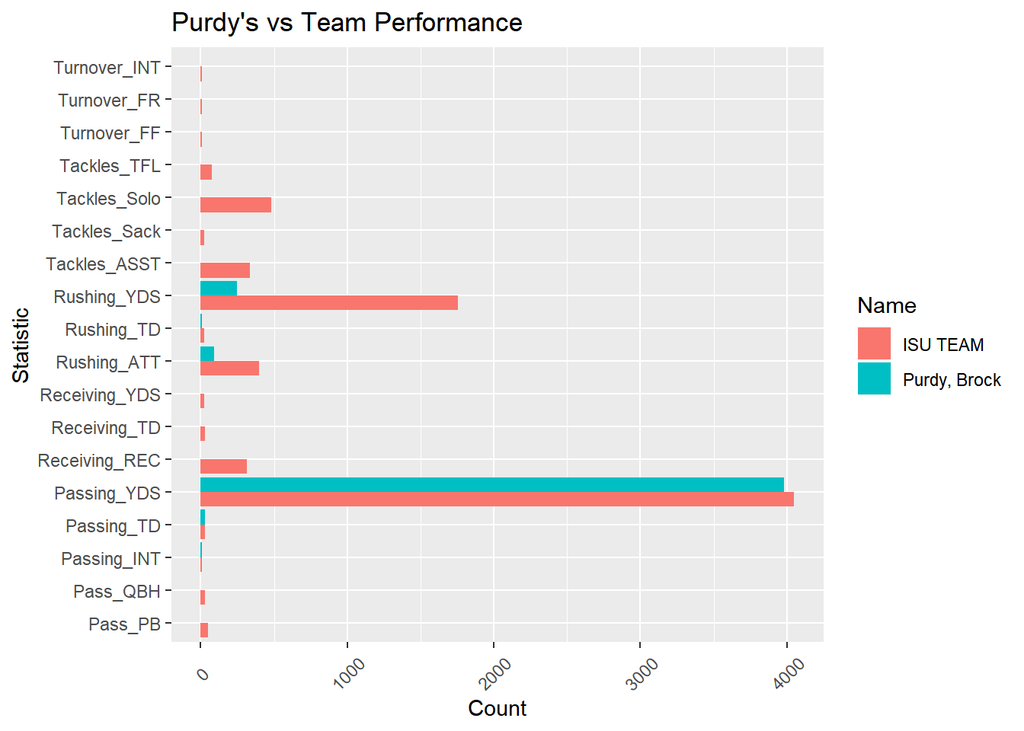

   ```r
   ggplot(data=completeISU, aes(x=Type, y = Statistics, fill = Name)) + geom_bar(stat='identity', position = position_dodge()) + theme(axis.text.x = element_text(angle =45, vjust = 0.5)) + xlab("Statistic") + ylab('Count') + ggtitle("Purdy's vs Team Performance ") + coord_flip()
   ```

   - Based on output above you can see how the teams performance compares to Purdys performance. I would say that in most areas that when Purdy performs well in his respective statistics (all passing stats) the team peforms well too.

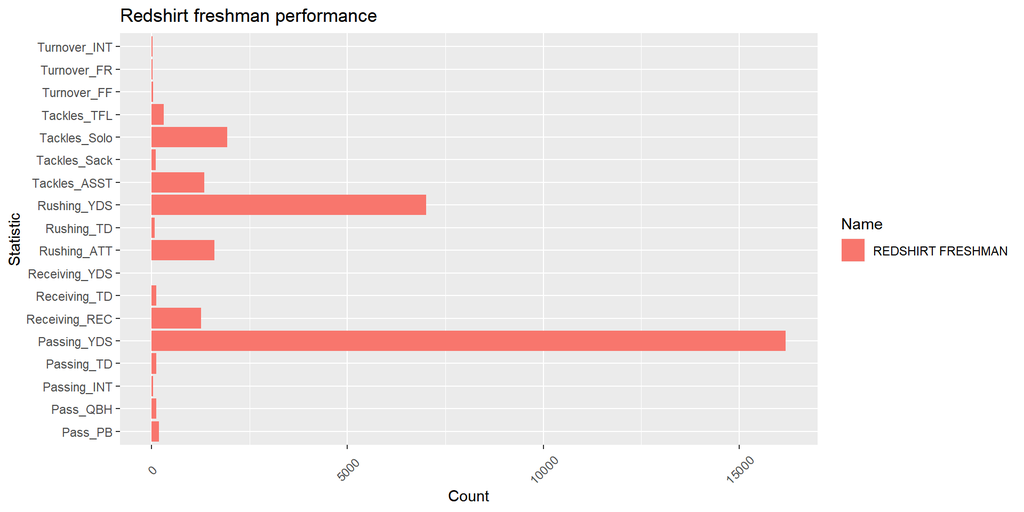

   ```r
   #Question: What statistic do redshirt freshman excel in?
   age<- full_join(avgISU, bioClean, by= c('Name'))

   redshirtFreshman<- age %>%
     filter(Class %in% c('Redshirt Freshman')) %>%
     mutate(Rushing_ATT = sum(Rushing_ATT, na.rm = TRUE)) %>%
     mutate(Rushing_YDS = sum(Rushing_YDS, na.rm = TRUE)) %>%
     mutate(Rushing_TD = sum(Rushing_TD, na.rm = TRUE)) %>%
     mutate(Receiving_REC = sum(Receiving_REC, na.rm = TRUE)) %>%
     mutate(Receiving_TD = sum(Receiving_TD, na.rm = TRUE)) %>%
     mutate(Passing_YDS = sum(Passing_YDS, na.rm = TRUE)) %>%
     mutate(Passing_TD = sum(Passing_TD, na.rm = TRUE)) %>%
     mutate(Passing_INT = sum(Passing_INT, na.rm = TRUE)) %>%
     mutate(Tackles_Solo = sum(Tackles_Solo, na.rm = TRUE)) %>%
     mutate(Tackles_ASST = sum(Tackles_ASST, na.rm = TRUE)) %>%
     mutate(Tackles_TFL = sum(Tackles_TFL, na.rm = TRUE)) %>%
     mutate(Tackles_Sack = sum(Tackles_Sack, na.rm = TRUE)) %>%
     mutate(Turnover_FF = sum(Turnover_FF, na.rm = TRUE)) %>%
     mutate(Turnover_FR = sum(Turnover_FR, na.rm = TRUE)) %>%
     mutate(Turnover_INT = sum(Turnover_INT, na.rm = TRUE)) %>%
     mutate(Pass_QBH = sum(Pass_QBH, na.rm = TRUE)) %>%
     mutate(Pass_PB = sum(Pass_PB, na.rm = TRUE))

   redshirtFreshman1<- head(redshirtFreshman, 1)
   redshirtFreshman2<- select(redshirtFreshman1, -c(Opponent_Opponent))
   redshirtFreshman3<- redshirtFreshman2 %>%
     pivot_longer(2:19, names_to = 'Type', values_to = 'Statistics') %>%
     mutate(Name = "REDSHIRT FRESHMAN")


   ggplot(data=redshirtFreshman3, aes(x=Type, y = Statistics, fill = Name)) + geom_bar(stat='identity', position = position_dodge()) + theme(axis.text.x = element_text(angle =45, vjust = 0.5)) + xlab("Statistic") + ylab('Count') + ggtitle("Redshirt freshman performance") + coord_flip()
   ```

   - Redshirt freshman based on the output above seem to perform the best in the amount of passing yards achieved.